# Part_I_exploration_template

- INTRODUCTION
- Dataset Structure
- UNIVARIATE EXPLORATION
- Univariate Findings
- BIVARIATE EXPLORATION
- Bivariate Findings
- MULTIVARIATE EXPLORATION
- Multivariate Findings
- CONCLUSION

*goto top*

# Part I - (Excellent Store Data Exploration)

## Introduction

> This document explores a dataset containing returns and attributes of different stores owned by an individual

## Preliminary Wrangling

```python
# import all packages and set plots to be embedded inline
import numpy as np
import pandas as pd
import matplotlib.pyplot as plt
import seaborn as sns

%matplotlib inline
```

```python
store_data = pd.read_csv('excellent.csv')
store_data.head()
```

|  | Item_ID | Store_ID | Item_Store_ID | Item_Weight | Item_Sugar_Content | Item_Visibility | Item_Type | Item_Price | Store_Start_Year | Store_Size | Store_Location_Type | Store_Type | Item_Store_Returns |
| --- | --- | --- | --- | --- | --- | --- | --- | --- | --- | --- | --- | --- | --- |
| 0 | DRA12 | BABATUNJI010 | DRA12_BABATUNJI010 | 11.6 | Low Sugar | 0.068535 | Soft Drinks | 357.54 | 2005 | NaN | Cluster 3 | Grocery Store | 709.08 |
| 1 | DRA12 | BABATUNJI013 | DRA12_BABATUNJI013 | 11.6 | Low Sugar | 0.040912 | Soft Drinks | 355.79 | 1994 | High | Cluster 3 | Supermarket Type1 | 6381.69 |
| 2 | DRA12 | BABATUNJI017 | DRA12_BABATUNJI017 | 11.6 | Low Sugar | 0.041178 | Soft Drinks | 350.79 | 2014 | NaN | Cluster 2 | Supermarket Type1 | 6381.69 |
| 3 | DRA12 | BABATUNJI018 | DRA12_BABATUNJI018 | 11.6 | Low Sugar | 0.041113 | Soft Drinks | 355.04 | 2016 | Medium | Cluster 3 | Supermarket Type2 | 2127.23 |
| 4 | DRA12 | BABATUNJI035 | DRA12_BABATUNJI035 | 11.6 | Ultra Low Sugar | 0.000000 | Soft Drinks | 354.79 | 2011 | Small | Cluster 2 | Supermarket Type1 | 2481.77 |

```python
store_data.info()
```

```
<class 'pandas.core.frame.DataFrame'>
RangeIndex: 4990 entries, 0 to 4989
Data columns (total 13 columns):
 #   Column               Non-Null Count  Dtype
---  ------               --------------  -----
 0   Item_ID              4990 non-null   object
 1   Store_ID             4990 non-null   object
 2   Item_Store_ID        4990 non-null   object
 3   Item_Weight          4188 non-null   float64
 4   Item_Sugar_Content   4990 non-null   object
 5   Item_Visibility      4990 non-null   float64
 6   Item_Type            4990 non-null   object
 7   Item_Price           4990 non-null   float64
 8   Store_Start_Year     4990 non-null   int64
 9   Store_Size           3540 non-null   object
 10  Store_Location_Type  4990 non-null   object
 11  Store_Type           4990 non-null   object
 12  Item_Store_Returns   4990 non-null   float64
dtypes: float64(4), int64(1), object(8)
memory usage: 506.9+ KB
```

```python
store_data.nunique()
```

```
Item_ID                1451
Store_ID                 10
Item_Store_ID          4990
Item_Weight             399
Item_Sugar_Content        3
Item_Visibility        4638
Item_Type                16
Item_Price             3522
Store_Start_Year          9
Store_Size                3
Store_Location_Type       3
Store_Type                4
Item_Store_Returns     2686
dtype: int64
```

```python
store_data.describe()
```

|  | Item_Weight | Item_Visibility | Item_Price | Store_Start_Year | Item_Store_Returns |
| --- | --- | --- | --- | --- | --- |
| count | 4188.000000 | 4990.000000 | 4990.000000 | 4990.000000 | 4990.000000 |
| mean | 12.908838 | 0.066916 | 391.803796 | 2004.783567 | 6103.520164 |
| std | 4.703256 | 0.053058 | 119.378259 | 8.283151 | 4447.333835 |
| min | 4.555000 | 0.000000 | 78.730000 | 1992.000000 | 83.230000 |
| 25% | 8.767500 | 0.027273 | 307.890000 | 1994.000000 | 2757.660000 |
| 50% | 12.600000 | 0.053564 | 393.860000 | 2006.000000 | 5374.675000 |
| 75% | 17.100000 | 0.095358 | 465.067500 | 2011.000000 | 8522.240000 |
| max | 21.350000 | 0.328391 | 667.220000 | 2016.000000 | 32717.410000 |

```python
(store_data.isnull().sum()/store_data.shape[0]) * 100
```

```
Item_ID                 0.000000
Store_ID                0.000000
Item_Store_ID           0.000000
Item_Weight            16.072144
Item_Sugar_Content      0.000000
Item_Visibility         0.000000
Item_Type               0.000000
Item_Price              0.000000
Store_Start_Year        0.000000
Store_Size             29.058116
Store_Location_Type     0.000000
Store_Type              0.000000
Item_Store_Returns      0.000000
dtype: float64
```

```python
store = store_data.copy()
store.sample(5)
```

|  | Item_ID | Store_ID | Item_Store_ID | Item_Weight | Item_Sugar_Content | Item_Visibility | Item_Type | Item_Price | Store_Start_Year | Store_Size | Store_Location_Type | Store_Type | Item_Store_Returns |
| --- | --- | --- | --- | --- | --- | --- | --- | --- | --- | --- | --- | --- | --- |
| 4180 | NCF30 | BABATUNJI049 | NCF30_BABATUNJI049 | 17.00 | Low Sugar | 0.126440 | Household | 313.09 | 2006 | Medium | Cluster 1 | Supermarket Type1 | 3460.50 |
| 2637 | FDR35 | BABATUNJI035 | FDR35_BABATUNJI035 | 12.50 | Low Sugar | 0.020694 | Breads | 497.94 | 2011 | Small | Cluster 2 | Supermarket Type1 | 10949.08 |
| 3905 | FDZ23 | BABATUNJI027 | FDZ23_BABATUNJI027 | NaN | Normal Sugar | 0.067176 | Baking Goods | 467.81 | 1992 | Medium | Cluster 3 | Supermarket Type3 | 9321.20 |
| 2121 | FDN40 | BABATUNJI046 | FDN40_BABATUNJI046 | 5.88 | Low Sugar | 0.000000 | Frozen Foods | 385.75 | 2004 | Small | Cluster 1 | Supermarket Type1 | 4998.49 |
| 2596 | FDR22 | BABATUNJI046 | FDR22_BABATUNJI046 | 19.35 | Normal Sugar | 0.018563 | Snack Foods | 276.39 | 2004 | Small | Cluster 1 | Supermarket Type1 | 3914.90 |

```python
store['Item_Weight'] = store['Item_Weight'].fillna(store['Item_Weight'].mean())
store.info()
```

```
<class 'pandas.core.frame.DataFrame'>
RangeIndex: 4990 entries, 0 to 4989
Data columns (total 13 columns):
 #   Column               Non-Null Count  Dtype
---  ------               --------------  -----
 0   Item_ID              4990 non-null   object
 1   Store_ID             4990 non-null   object
 2   Item_Store_ID        4990 non-null   object
 3   Item_Weight          4990 non-null   float64
 4   Item_Sugar_Content   4990 non-null   object
 5   Item_Visibility      4990 non-null   float64
 6   Item_Type            4990 non-null   object
 7   Item_Price           4990 non-null   float64
 8   Store_Start_Year     4990 non-null   int64
 9   Store_Size           3540 non-null   object
 10  Store_Location_Type  4990 non-null   object
 11  Store_Type           4990 non-null   object
 12  Item_Store_Returns   4990 non-null   float64
dtypes: float64(4), int64(1), object(8)
memory usage: 506.9+ KB
```

```python
store.sample(5)
```

|  | Item_ID | Store_ID | Item_Store_ID | Item_Weight | Item_Sugar_Content | Item_Visibility | Item_Type | Item_Price | Store_Start_Year | Store_Size | Store_Location_Type | Store_Type | Item_Store_Returns |
| --- | --- | --- | --- | --- | --- | --- | --- | --- | --- | --- | --- | --- | --- |
| 4351 | NCK19 | BABATUNJI018 | NCK19_BABATUNJI018 | 9.800000 | Low Sugar | 0.090834 | Others | 480.62 | 2016 | Medium | Cluster 3 | Supermarket Type2 | 10171.76 |
| 1626 | FDJ21 | BABATUNJI049 | FDJ21_BABATUNJI049 | 16.700000 | Normal Sugar | 0.038588 | Snack Foods | 361.53 | 2006 | Medium | Cluster 1 | Supermarket Type1 | 8384.09 |
| 3295 | FDV38 | BABATUNJI013 | FDV38_BABATUNJI013 | 19.250000 | Low Sugar | 0.101689 | Dairy | 136.74 | 1994 | High | Cluster 3 | Supermarket Type1 | 409.47 |
| 1594 | FDJ07 | BABATUNJI017 | FDJ07_BABATUNJI017 | 7.260000 | Low Sugar | 0.014505 | Meat | 296.04 | 2014 | NaN | Cluster 2 | Supermarket Type1 | 4369.31 |
| 1267 | FDG17 | BABATUNJI027 | FDG17_BABATUNJI027 | 12.908838 | Normal Sugar | 0.035667 | Frozen Foods | 615.62 | 1992 | Medium | Cluster 3 | Supermarket Type3 | 20158.76 |

```python
store.dtypes
```

```
Item_ID                 object
Store_ID                object
Item_Store_ID           object
Item_Weight            float64
Item_Sugar_Content      object
Item_Visibility        float64
Item_Type               object
Item_Price             float64
Store_Start_Year         int64
Store_Size              object
Store_Location_Type     object
Store_Type              object
Item_Store_Returns     float64
dtype: object
```

*goto top*

### What is the structure of your dataset?

> - There are 4,990 records of stores with 13 features (Item_ID, Store_ID, Item_Store_ID, Item_Weight, Item_Sugar_Content, Item_Visibility, Item_Type, Item_Price, Store_Start_Year, Store_Size, Store_Location_Type, Store_Type and Item_Store_Returns).
> - There are 8 Catgorical variables and 5 numerical variables. There are also aout 16% missing data Item_weight variable and 29% in the store_size.

### What is/are the main feature(s) of interest in your dataset?

> - I'm interested in figuring what feature affects the return, does the size of the store, or its location type or even item type affect the return?

### What features in the dataset do you think will help support your investigation into your feature(s) of interest?

> I believe the `Store_Type`, `Store_Size`, and `Store_Location_Type`, and `Item_Store_Returns` will give me insights on what store has the highest return. I would also be looking at the `Item_Type` and `Item_Price`

*goto top*

## Univariate Exploration

##### I will start by looking at the `Item_Store_Returns` feature

> - What is the distribution like?

```python
store['Item_Store_Returns'].describe()
```

```
count     4990.000000
mean      6103.520164
std       4447.333835
min         83.230000
25%       2757.660000
50%       5374.675000
75%       8522.240000
max      32717.410000
Name: Item_Store_Returns, dtype: float64
```

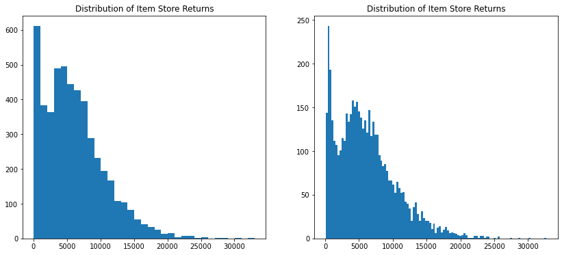

```python
plt.figure(figsize=(14, 6))


plt.subplot(1,2,1)
binsize = 1000
bins = np.arange(50, store['Item_Store_Returns'].max()+binsize, binsize)
plt.hist(x='Item_Store_Returns', data=store, bins=bins);
plt.title('Distribution of Item Store Returns')

plt.subplot(1,2,2)
binsize = 300
bins = np.arange(50, store['Item_Store_Returns'].max()+binsize, binsize)
plt.hist(x='Item_Store_Returns', data=store, bins=bins)
plt.title('Distribution of Item Store Returns');
```

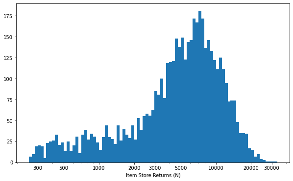

```python
plt.figure(figsize=(10, 6))

log_binsize = 0.025
bins = 10**np.arange(2.4, np.log10(store['Item_Store_Returns'].max())+log_binsize, log_binsize)
ticks = [300, 500, 1e3, 2e3, 3e3, 5e3, 1e4, 2e4, 3e4]
labels = [f'{i:.0f}' for i in ticks]

plt.hist(x='Item_Store_Returns', data=store, bins=bins)
plt.xscale('log')
plt.xticks(ticks, labels)
plt.xlabel('Item Store Returns (N)');
```

> - The item returns has a long tail with majority of the return price falling below 10,000 and few above 10,000. Using the log scale, a peak is seen at 8000

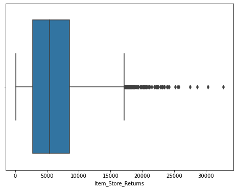

```python
plt.figure(figsize=(8, 6))

sns.boxplot(x=store['Item_Store_Returns']);
```

> - There are lots of outliers in this column, some items yielded returns greater than the majority (N18,000 above)

##### Looking at the `Store_ID` feature

```python
# checking if the number_ID determines the how old or recent the store is
store.groupby('Store_ID')['Store_Start_Year'].mean()
```

```
Store_ID
BABATUNJI010    2005
BABATUNJI013    1994
BABATUNJI017    2014
BABATUNJI018    2016
BABATUNJI019    1992
BABATUNJI027    1992
BABATUNJI035    2011
BABATUNJI045    2009
BABATUNJI046    2004
BABATUNJI049    2006
Name: Store_Start_Year, dtype: int64
```

> - There are 10 stores captured in this dataset
> - The Store_ID doesn't appear to be an ordinal data. The numbers in the IDs don't mean the store is recent or old

```python
id_count = store['Store_ID'].value_counts()
```

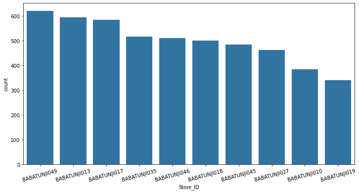

```python
plt.figure(figsize=(12, 6))
basecolor = sns.color_palette()[0]
sns.countplot(x='Store_ID', data=store, color=basecolor, order=id_count.index)
plt.xticks(rotation=15);
```

##### Looking at the distribution of the `Item_weight` feature

```python
store['Item_Weight'].describe()
```

```
count    4990.000000
mean       12.908838
std         4.308671
min         4.555000
25%         9.300000
50%        12.908838
75%        16.250000
max        21.350000
Name: Item_Weight, dtype: float64
```

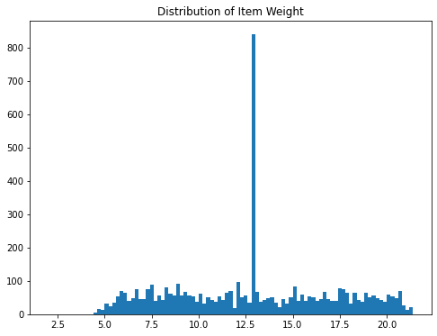

```python
plt.figure(figsize=(8, 6))

binsize = 0.2
bins = np.arange(2, store['Item_Weight'].max()+binsize, binsize)
plt.hist(x='Item_Weight', data=store, bins=bins)
plt.title('Distribution of Item Weight');
```

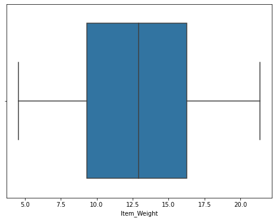

```python
plt.figure(figsize=(8, 6))

sns.boxplot(x=store['Item_Weight']);
```

##### I want to look at the `Item_Price` feature

```python
store['Item_Price'].describe()
```

```
count    4990.000000
mean      391.803796
std       119.378259
min        78.730000
25%       307.890000
50%       393.860000
75%       465.067500
max       667.220000
Name: Item_Price, dtype: float64
```

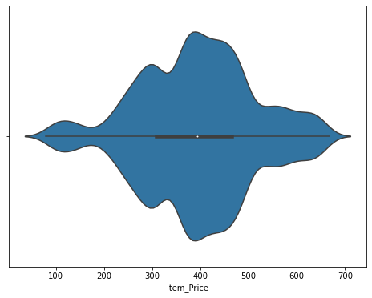

```python
plt.figure(figsize=(8, 6))

sns.violinplot(x=store['Item_Price']);
```

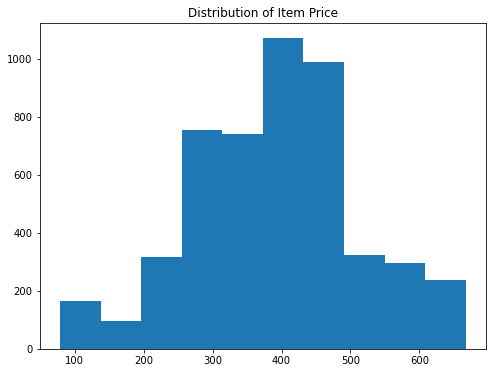

```python
plt.figure(figsize=(8, 6))

plt.hist(x='Item_Price', data=store)
plt.title('Distribution of Item Price');
```

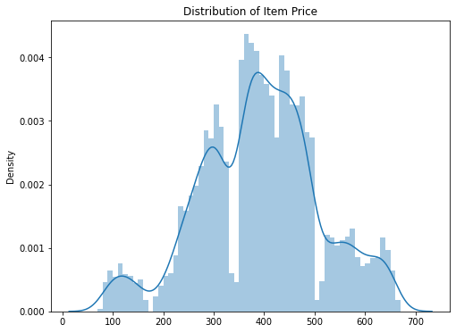

```python
plt.figure(figsize=(8, 6))

binsize = 10
bins = np.arange(50, store['Item_Price'].max()+binsize, binsize)
sns.distplot(x=store['Item_Price'], bins=bins, kde=True)
plt.title('Distribution of Item Price');
```

> - The distribution is slightly left skewed, a steep jump can be seen just before the 350 price and a peak recorded at around 390.

```python
store.columns
```

```
Index(['Item_ID', 'Store_ID', 'Item_Store_ID', 'Item_Weight',
       'Item_Sugar_Content', 'Item_Visibility', 'Item_Type', 'Item_Price',
       'Store_Start_Year', 'Store_Size', 'Store_Location_Type', 'Store_Type',
       'Item_Store_Returns'],
      dtype='object')
```

##### What `Item_Type` do the stores have generally?

```python
store['Item_Type'].nunique()
```

```
16
```

```python
item_count = store['Item_Type'].value_counts()
item_count
```

```
Snack Foods              758
Fruits and Vegetables    747
Household                567
Frozen Foods             457
Canned                   376
Dairy                    350
Baking Goods             344
Health and Hygiene       307
Meat                     264
Soft Drinks              261
Breads                   137
Hard Drinks              134
Others                   100
Starchy Foods             81
Breakfast                 66
Seafood                   41
Name: Item_Type, dtype: int64
```

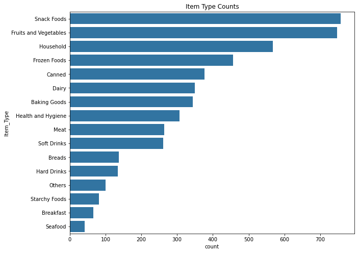

```python
plt.figure(figsize=(10, 8))
sns.countplot(y='Item_Type', data=store, color=basecolor, order=item_count.index)
plt.title('Item Type Counts');
```

> - There are 16 Item types stocked in the stores
> - The stores are stocked mostly with **Snack Foods** and **Fruits and Vegetable**

##### Exploring the `Store_Location_Type`

```python
location_count = store['Store_Location_Type'].value_counts()
location_count
```

```
Cluster 3    1940
Cluster 2    1581
Cluster 1    1469
Name: Store_Location_Type, dtype: int64
```

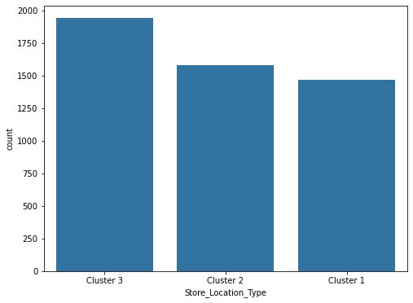

```python
plt.figure(figsize=(8, 6))
sns.countplot(x=store['Store_Location_Type'], color=basecolor);
```

##### Exploring the `Store_Type`

```python
type_count = store['Store_Type'].value_counts()
type_count
```

```
Supermarket Type1    3304
Grocery Store         724
Supermarket Type2     500
Supermarket Type3     462
Name: Store_Type, dtype: int64
```

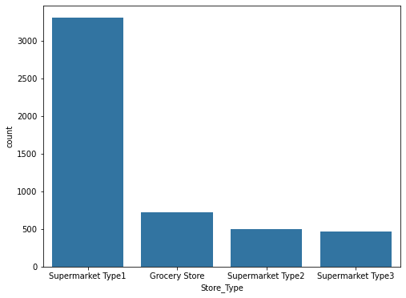

```python
plt.figure(figsize=(8, 6))
sns.countplot(x=store['Store_Type'], color=basecolor, order=type_count.index);
```

*goto top*

### Discuss the distribution(s) of your variable(s) of interest. Were there any unusual points? Did you need to perform any transformations?

> - The range of values in the Item_store_return is large, so I used a log transform to view the data. I noticed majority of the return price falling below N10,000 and few above N10,000. Then a peak in frequency is seen at around N8,000.

## Bivariate Exploration

```python
store.sample(2)
```

|  | Item_ID | Store_ID | Item_Store_ID | Item_Weight | Item_Sugar_Content | Item_Visibility | Item_Type | Item_Price | Store_Start_Year | Store_Size | Store_Location_Type | Store_Type | Item_Store_Returns |
| --- | --- | --- | --- | --- | --- | --- | --- | --- | --- | --- | --- | --- | --- |
| 2245 | FDO46 | BABATUNJI027 | FDO46_BABATUNJI027 | 12.908838 | Normal Sugar | 0.014144 | Snack Foods | 468.47 | 1992 | Medium | Cluster 3 | Supermarket Type3 | 7090.77 |
| 4765 | NCT18 | BABATUNJI027 | NCT18_BABATUNJI027 | 12.908838 | Low Sugar | 0.059117 | Household | 453.99 | 1992 | Medium | Cluster 3 | Supermarket Type3 | 10413.11 |

**I want to look at the correlation of the numeric variables in the dataset**

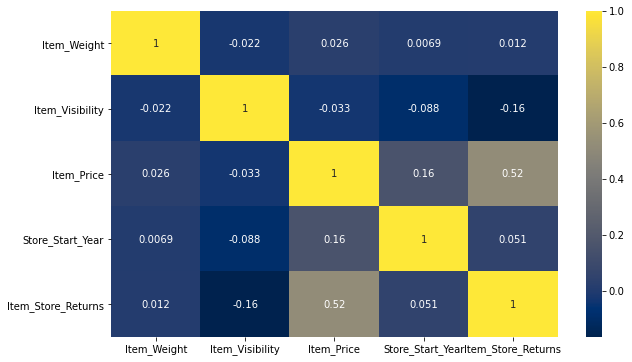

```python
plt.figure(figsize=(10, 6))
sns.heatmap(store.corr(), annot=True, cmap='cividis');
```

> - Of all the variables, only the Item_Price and Item_Visibility have some correlation with the returns.
> - The Item_price has a medium positive correlation with the returns while Item_visibility has a low negative correlation with the returns

##### I want to see the relationship between the `Item price` and their returns

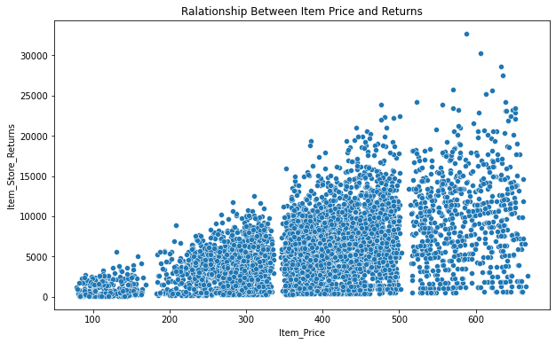

```python
# check Item Price with returns
plt.figure(figsize=(10, 6))
sns.scatterplot(y='Item_Store_Returns', x='Item_Price', data=store)
plt.title('Ralationship Between Item Price and Returns');
```

> - There seems to be a slightly/medium positive correlation between the price of the items and their returns

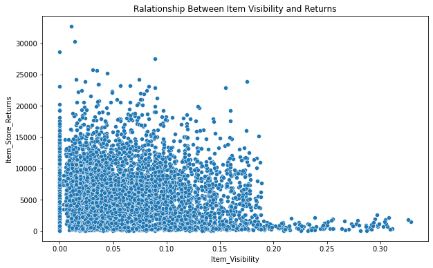

```python
plt.figure(figsize=(10, 6))
sns.scatterplot(y='Item_Store_Returns', x='Item_Visibility', data=store)
plt.title('Ralationship Between Item Visibility and Returns');
```

> - One would expect that an item's visibility would cause it to bring great returns, but surprisingly, they have a negative correlation, although it is a weak one. The less visible items appears to have better returns than the visible ones

```python
store.nunique()
```

```
Item_ID                1451
Store_ID                 10
Item_Store_ID          4990
Item_Weight             400
Item_Sugar_Content        3
Item_Visibility        4638
Item_Type                16
Item_Price             3522
Store_Start_Year          9
Store_Size                3
Store_Location_Type       3
Store_Type                4
Item_Store_Returns     2686
dtype: int64
```

```python
store['Store_Type'].unique()
```

```
array(['Grocery Store', 'Supermarket Type1', 'Supermarket Type2',
       'Supermarket Type3'], dtype=object)
```

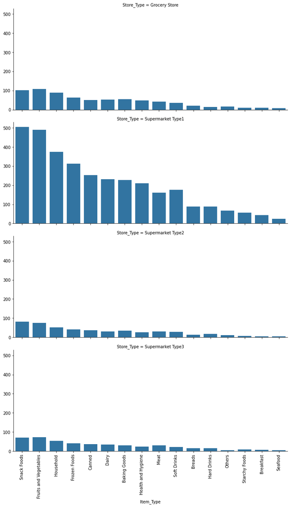

```python
g = sns.FacetGrid(data=store, row='Store_Type', height=4, aspect=2.5)
g.map(sns.countplot, "Item_Type", order=item_count.index)
plt.xticks(rotation=90);
```

> - Each store has more stock of **Snack Foods, Fruits and Vegetables and Household Item types**

```python
item_type = store.groupby('Item_Type')[['Item_Store_Returns']].sum().sort_values('Item_Store_Returns', ascending=False)
item_type = item_type.reset_index()
item_type
```

|  | Item_Type | Item_Store_Returns |
| --- | --- | --- |
| 0 | Fruits and Vegetables | 4753680.69 |
| 1 | Snack Foods | 4744323.12 |
| 2 | Household | 3488712.43 |
| 3 | Frozen Foods | 2750915.93 |
| 4 | Canned | 2334080.29 |
| 5 | Dairy | 2173104.79 |
| 6 | Baking Goods | 1944151.22 |
| 7 | Health and Hygiene | 1657208.00 |
| 8 | Meat | 1606164.39 |
| 9 | Soft Drinks | 1573069.09 |
| 10 | Breads | 835605.63 |
| 11 | Hard Drinks | 805083.80 |
| 12 | Starchy Foods | 567892.48 |
| 13 | Others | 556334.25 |
| 14 | Breakfast | 403681.24 |
| 15 | Seafood | 262558.27 |

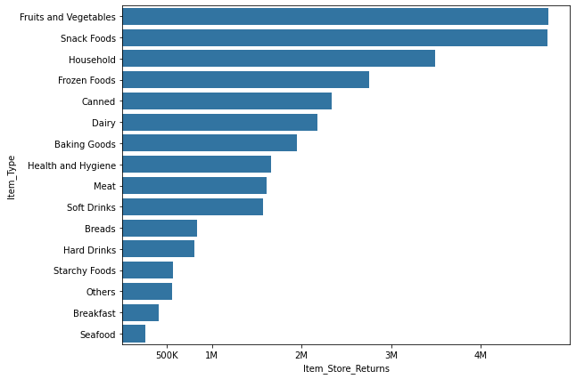

```python
plt.figure(figsize=(9, 7))
sns.barplot(y='Item_Type', x='Item_Store_Returns', data=item_type, color=basecolor);
ticks = [5e5, 1e6, 2e6, 3e6, 4e6]
labels=['500K', '1M', '2M', '3M', '4M']
plt.xticks(ticks, labels);
```

> - `Fruits and Vegetable` and `Snack Foods` yielded the highest returns. This makes sense since most of the stores were mostly stocked with these items

```python
store_size = store['Store_Size'].value_counts().iloc[[1, 0, 2]]
store_size
```

```
Small     1364
Medium    1582
High       594
Name: Store_Size, dtype: int64
```

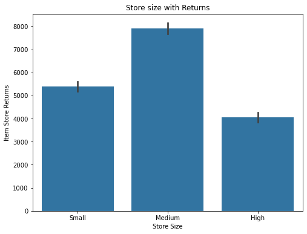

```python
plt.figure(figsize=(8, 6))
sns.barplot(x='Store_Size', y='Item_Store_Returns', data=store, color=basecolor, order=store_size.index)
plt.title('Store size with Returns')
plt.xlabel('Store Size')
plt.ylabel('Item Store Returns');
```

> - The Medium sized store has the highest return

```python
location = store['Store_Location_Type'].value_counts().iloc[[2, 1, 0]]
location
```

```
Cluster 1    1469
Cluster 2    1581
Cluster 3    1940
Name: Store_Location_Type, dtype: int64
```

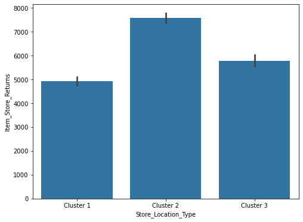

```python
plt.figure(figsize=(8, 6))
sns.barplot(x='Store_Location_Type', y='Item_Store_Returns', data=store, color=basecolor, order=location.index);
```

> - Stores in Cluster 2 location type has the highest returns

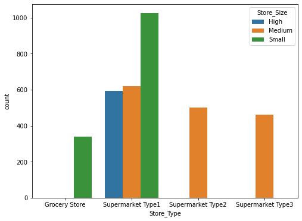

```python
plt.figure(figsize=(8, 6))
sns.countplot(x='Store_Type', hue='Store_Size', data=store);
```

```python
store.groupby('Store_Type')['Item_Store_Returns'].mean().sort_values(ascending=False)
```

```
Store_Type
Supermarket Type3    12561.189697
Supermarket Type1     6442.040623
Supermarket Type2     5540.621680
Grocery Store          826.633867
Name: Item_Store_Returns, dtype: float64
```

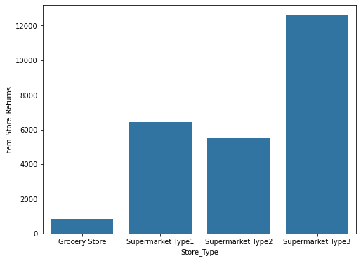

```python
plt.figure(figsize=(8, 6))
sns.barplot(x='Store_Type', y='Item_Store_Returns', data=store, color=basecolor, ci=None);
```

*goto top*

### Talk about some of the relationships you observed in this part of the investigation. How did the feature(s) of interest vary with other features in the dataset?

> - `Item_Price` and `Item_Visibility` have some correlation with the `Item_Price_Returns`. The higher the price of an item, the higher its return. I would've thought the visibility of the item would mean higher returns but the opposite is the case as the less visible items had higher returns than the more visible ones

### Did you observe any interesting relationships between the other features (not the main feature(s) of interest)?

> - Only Supermarket Type1 has all three sizes of store. The Grocery store type is a small sized store and Supermarket Type2 and 3 are medium sized stores. Interestingly, Supermarket Type3 has better returns than the rest on the average

## Multivariate Exploration

```python
store.head(2)
```

|  | Item_ID | Store_ID | Item_Store_ID | Item_Weight | Item_Sugar_Content | Item_Visibility | Item_Type | Item_Price | Store_Start_Year | Store_Size | Store_Location_Type | Store_Type | Item_Store_Returns |
| --- | --- | --- | --- | --- | --- | --- | --- | --- | --- | --- | --- | --- | --- |
| 0 | DRA12 | BABATUNJI010 | DRA12_BABATUNJI010 | 11.6 | Low Sugar | 0.068535 | Soft Drinks | 357.54 | 2005 | NaN | Cluster 3 | Grocery Store | 709.08 |
| 1 | DRA12 | BABATUNJI013 | DRA12_BABATUNJI013 | 11.6 | Low Sugar | 0.040912 | Soft Drinks | 355.79 | 1994 | High | Cluster 3 | Supermarket Type1 | 6381.69 |

```python
np.random.seed(1000)
sample = np.random.choice(store.shape[0], 500, replace=False)
store_sub = store.loc[sample]
```

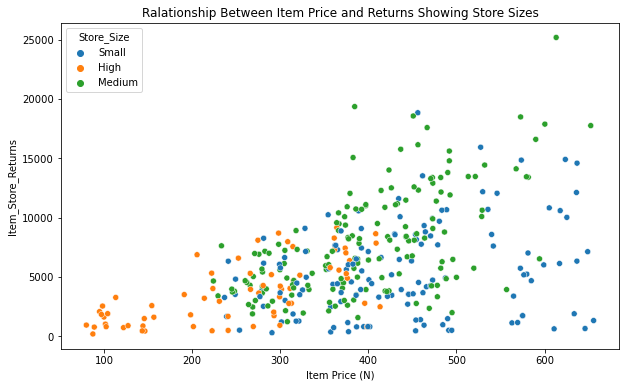

```python
plt.figure(figsize=(10, 6))
sns.scatterplot(y='Item_Store_Returns', x='Item_Price', data=store_sub, hue='Store_Size')
plt.title('Ralationship Between Item Price and Returns Showing Store Sizes')
plt.xlabel('Item Price (N)');
```

> - Small and Medium sized stores were not stocked with items with prices less than N220. Most of the high priced items are in the small sized store. Studying the Medium sized store however, many items are within the price 250 and 500 and their returns are high compare to the other store sizes. Interestingly, The High store sizes were stocked with items with the least price. No wonder the returns were not very high there as seen in a previous visualization

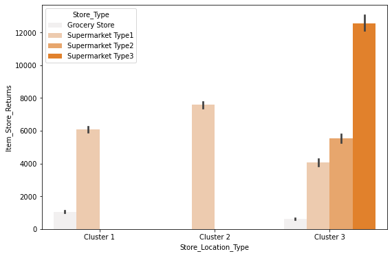

```python
plt.figure(figsize=(9, 6))
basecolor = sns.color_palette()[1]
sns.barplot(x='Store_Location_Type', y='Item_Store_Returns', hue='Store_Type', data=store, color=basecolor, order=location.index);
```

*goto top*

### Talk about some of the relationships you observed in this part of the investigation. Were there features that strengthened each other in terms of looking at your feature(s) of interest?

> Small and Medium sized stores were not stocked with items with prices less than N220. Most of the high priced items are in the small sized store. Studying the Medium sized store however, many items are within the price 250 and 500 and their returns are high compare to the other store sizes. Interestingly, The High store sizes were stocked with items with the least price. No wonder the returns were not very high there as seen in a previous visualization

## Conclusions

> The Item_Price, Item_Type, Store_Type and Store_Loaction_Type are features that affect the yield in return of the items.